# Personal Project: Predicting Hourly Wage

## Introduction

This notebook builds and compares four machine learning models to investigate factors influencing hourly wages using the *Beauty* dataset in *Introductory Econometrics: A Modern Approach* (J.M. Wooldridge) The analysis is divided into two parts:

1. Implement Ridge and Lasso Regression.
2. Implement Random Forest and Neural Network, then provide a comparison of four models, and interpret relevant findings.

# 1. Ridge and Lasso Regression for Hourly Wage Prediction

## 1.1. Data Preparation

### Data Loading

```python
# Basic Setup and Imports
import pandas as pd
import matplotlib.pyplot as plt
import seaborn as sns
import numpy as np

from sklearn.model_selection import train_test_split
from sklearn.preprocessing import StandardScaler
from sklearn.linear_model import RidgeCV, LassoCV
from sklearn.metrics import root_mean_squared_error, r2_score
from IPython.display import display, HTML # Display options
```

```python
# Load the dataset
beauty = pd.read_csv('BEAUTY.csv')
beauty.describe()
```

|  | wage | lwage | belavg | abvavg | exper | looks | union | goodhlth | black | female | married | south | bigcity | smllcity | service | expersq | educ |
| --- | --- | --- | --- | --- | --- | --- | --- | --- | --- | --- | --- | --- | --- | --- | --- | --- | --- |
| count | 1260.000000 | 1260.000000 | 1260.000000 | 1260.000000 | 1260.000000 | 1260.000000 | 1260.000000 | 1260.000000 | 1260.000000 | 1260.000000 | 1260.000000 | 1260.000000 | 1260.000000 | 1260.000000 | 1260.000000 | 1260.000000 | 1260.000000 |
| mean | 6.306690 | 1.658800 | 0.123016 | 0.303968 | 18.206349 | 3.185714 | 0.272222 | 0.933333 | 0.073810 | 0.346032 | 0.691270 | 0.174603 | 0.219048 | 0.466667 | 0.273810 | 474.482540 | 12.563492 |
| std | 4.660639 | 0.594508 | 0.328586 | 0.460152 | 11.963485 | 0.684877 | 0.445280 | 0.249543 | 0.261564 | 0.475892 | 0.462153 | 0.379778 | 0.413765 | 0.499086 | 0.446089 | 534.645425 | 2.624489 |
| min | 1.020000 | 0.019803 | 0.000000 | 0.000000 | 0.000000 | 1.000000 | 0.000000 | 0.000000 | 0.000000 | 0.000000 | 0.000000 | 0.000000 | 0.000000 | 0.000000 | 0.000000 | 0.000000 | 5.000000 |
| 25% | 3.707500 | 1.310357 | 0.000000 | 0.000000 | 8.000000 | 3.000000 | 0.000000 | 1.000000 | 0.000000 | 0.000000 | 0.000000 | 0.000000 | 0.000000 | 0.000000 | 0.000000 | 64.000000 | 12.000000 |
| 50% | 5.300000 | 1.667705 | 0.000000 | 0.000000 | 15.000000 | 3.000000 | 0.000000 | 1.000000 | 0.000000 | 0.000000 | 1.000000 | 0.000000 | 0.000000 | 0.000000 | 0.000000 | 225.000000 | 12.000000 |
| 75% | 7.695000 | 2.040570 | 0.000000 | 1.000000 | 27.000000 | 4.000000 | 1.000000 | 1.000000 | 0.000000 | 1.000000 | 1.000000 | 0.000000 | 0.000000 | 1.000000 | 1.000000 | 729.000000 | 13.000000 |
| max | 77.720000 | 4.353113 | 1.000000 | 1.000000 | 48.000000 | 5.000000 | 1.000000 | 1.000000 | 1.000000 | 1.000000 | 1.000000 | 1.000000 | 1.000000 | 1.000000 | 1.000000 | 2304.000000 | 17.000000 |

The dataset includes 1260 observations with wage information and 15 potential predictors. No missing values were found. Initial summary statistics reveal the target variable `wage` is right-skewed. Therefore, I also explore the distribution of `wage` and `lwage` below.

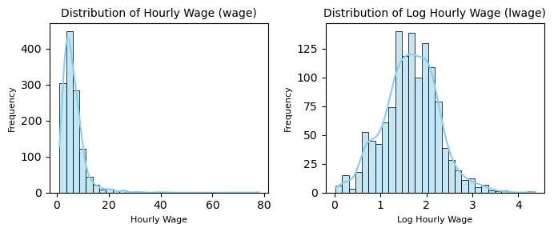

```python
# Distribution Plot
plt.figure(figsize=(7, 3))

# 1. Distribution of 'wage'
plt.subplot(1, 2, 1) # 1 row, 2 columns, first plot
sns.histplot(beauty['wage'], kde=True, bins=30, color='skyblue') # Histogram with a density curve
plt.title('Distribution of Hourly Wage (wage)',size =10)
plt.xlabel('Hourly Wage',size =8)
plt.ylabel('Frequency',size =8)

# 2. Distribution of 'lwage'
plt.subplot(1, 2, 2) # 1 row, 2 columns, second plot
sns.histplot(beauty['lwage'], kde=True, bins=30, color='skyblue')
plt.title('Distribution of Log Hourly Wage (lwage)',size =10)
plt.xlabel('Log Hourly Wage',size =8)
plt.ylabel('Frequency',size =8)

plt.tight_layout() # Adjust layout to prevent overlap
plt.show()
```

The distribution plots confirm `wage` is right-skewed, while `lwage` is closer to a normal distribution. Using the natural logarithm of wage `lwage` as the dependent variable for model training is expected to yield better results. Final model evaluation will be interpreted in both log and absolute wage.

### Data Splitting and Scaling

The data is split 70% training / 30% test. Since Ridge and Lasso coefficients are scale-sensitive, predictors are standardized using `StandardScaler` fitted only on the training data.

Feature selection: I exclude `looks` variable as its information is captured by the `belavg` and `abvavg` dummies, thus avoiding multicollinearity.

```python
# Split data into 70% training and 30% test set
train_set, test_set = train_test_split(beauty, test_size=0.3, random_state=42)

# Define Features (Predictors) and Target
X_cols = ['belavg', 'abvavg', 'exper', 'union',
       'goodhlth', 'black', 'female', 'married', 'south',
       'bigcity', 'smllcity', 'service', 'expersq', 'educ'] # 14 predictors, excluding `looks`
y_col = ['lwage']

X_train_orig = train_set[X_cols]
y_train_orig  = train_set[y_col].values.ravel() # lwage
X_test_orig  = test_set[X_cols]
y_test_orig = test_set[y_col].values.ravel() # lwage
y_test_wage = test_set['wage'].values.ravel() # Actual wage
```

```python
# Standardising the data using StandardScaler
scaler = StandardScaler()

# Fit on training data and transform both sets
X_train_scaled  = scaler.fit_transform(X_train_orig)
X_test_scaled = scaler.transform(X_test_orig)
```

## 1.2. Model Implementation and Evaluation

Next, I implement Ridge and Lasso using RidgeCV and LassoCV respectively, both with 10-fold cross-validation to select the optimal regularization parameter (alpha).

### Cross Validated Ridge Regression

Ridge uses L2 regularization, shrinking coefficients towards zero but typically not setting them exactly to zero.

```python
# Cross Validated Ridge Regression
ridge_cv = RidgeCV(cv=10, scoring='neg_root_mean_squared_error')
ridge_cv.fit(X_train_scaled, y_train_orig)

# Predict and evaluate on lwage scale
y_test_pred = ridge_cv.predict(X_test_scaled)
RMSE_lwage_ridge = root_mean_squared_error(y_test_orig, y_test_pred)
r2_lwage_ridge = ridge_cv.score(X_test_scaled, y_test_orig) # R-squared on lwage

# Evaluate on wage scale
y_test_wage_pred = np.exp(y_test_pred) # Transform lwage to wage predictions
RMSE_wage_ridge = root_mean_squared_error(y_test_wage, y_test_wage_pred)

print(f"\n--- Ridge Results ---")
print(f"Ridge Best Alpha: {ridge_cv.alpha_}")
print(f"Ridge RMSE (lwage scale): {RMSE_lwage_ridge}")
print(f"Ridge R-squared (lwage scale): {r2_lwage_ridge}")
print(f"Ridge RMSE (wage scale): {RMSE_wage_ridge}")

# Extract Ridge coefficients
ridge_coeffs = pd.Series(ridge_cv.coef_, index=X_cols)
```

```
--- Ridge Results ---
Ridge Best Alpha: 1.0
Ridge RMSE (lwage scale): 0.4409644837921741
Ridge R-squared (lwage scale): 0.43367922539448
Ridge RMSE (wage scale): 3.5740573219647516
```

### Cross Validated LASSO

Lasso uses L1 regularization, which can shrink coefficients exactly to zero, performing automatic feature selection.

```python
# Cross Validated Lasso Regression
lasso_cv = LassoCV(cv=10, random_state=42) # Added random_state for reproducible cross-validation fold generation
lasso_cv.fit(X_train_scaled, y_train_orig)

# Predict and evaluate on lwage scale
y_test_pred = lasso_cv.predict(X_test_scaled)
RMSE_lwage_lasso = root_mean_squared_error(y_test_orig, y_test_pred)
r2_lwage_lasso = lasso_cv.score(X_test_scaled, y_test_orig) # R-squared on lwage

# Evaluate on wage scale
y_test_wage_pred = np.exp(y_test_pred) # Transform lwage to wage predictions
RMSE_wage_lasso = root_mean_squared_error(y_test_wage, y_test_wage_pred)

print(f"\n--- Lasso Results ---")
print(f"Lasso Best Alpha: {lasso_cv.alpha_}")
print(f"Lasso RMSE (lwage scale): {RMSE_lwage_lasso}")
print(f"Lasso R-squared (lwage scale): {r2_lwage_lasso}")
print(f"Lasso RMSE (wage scale): {RMSE_wage_lasso}")

# Extract Lasso Feature Selection
lasso_coeffs = pd.Series(lasso_cv.coef_, index=X_cols)
non_zero_coeffs = np.sum(lasso_coeffs != 0)
print(f"\nNumber of features used by Lasso: {non_zero_coeffs} out of {len(X_cols)}")
```

```
--- Lasso Results ---
Lasso Best Alpha: 0.0005055586885587609
Lasso RMSE (lwage scale): 0.44101492477569104
Lasso R-squared (lwage scale): 0.4335496575417561
Lasso RMSE (wage scale): 3.5744144564418434

Number of features used by Lasso: 14 out of 14
```

## 1.3. Comparison and Summary

```python
# Compare Ridge and Lasso performance
results_data = {
    'RMSE (lwage scale)': [RMSE_lwage_ridge, RMSE_lwage_lasso],
    'RMSE (wage scale)': [RMSE_wage_ridge, RMSE_wage_lasso],
    'R-squared (lwage scale)': [r2_lwage_ridge, r2_lwage_lasso],
    'Best Alpha': [ridge_cv.alpha_, lasso_cv.alpha_],
    'Features Used': [len(X_cols), non_zero_coeffs] # Show total for Ridge, selected for Lasso
}
results_df = pd.DataFrame(results_data, index=['Ridge', 'Lasso'])
print ("The performance metrics and coefficients for Ridge and Lasso are compared below:\n")
display(results_df.style.format())

# Compare coefficients
print ("\n--- Coefficients Comparison (on lwage scale) ---")
coefficients_df = pd.DataFrame({
    'Ridge Coefficient': ridge_coeffs,
    'Lasso Coefficient': lasso_coeffs
})
# Format for readability
coefficients_df_formatted = coefficients_df.style.format('{:.4f}')
display(coefficients_df_formatted)
```

```
The performance metrics and coefficients for Ridge and Lasso are compared below:
```

|  | RMSE (lwage scale) | RMSE (wage scale) | R-squared (lwage scale) | Best Alpha | Features Used |
| --- | --- | --- | --- | --- | --- |
| Ridge | 0.440964 | 3.574057 | 0.433679 | 1.000000 | 14 |
| Lasso | 0.441015 | 3.574414 | 0.433550 | 0.000506 | 14 |

```
--- Coefficients Comparison (on lwage scale) ---
```

|  | Ridge Coefficient | Lasso Coefficient |
| --- | --- | --- |
| belavg | -0.0386 | -0.0383 |
| abvavg | 0.0110 | 0.0105 |
| exper | 0.4722 | 0.4708 |
| union | 0.0737 | 0.0733 |
| goodhlth | 0.0199 | 0.0195 |
| black | -0.0159 | -0.0154 |
| female | -0.1732 | -0.1733 |
| married | 0.0189 | 0.0184 |
| south | 0.0316 | 0.0312 |
| bigcity | 0.0998 | 0.0990 |
| smllcity | 0.0399 | 0.0391 |
| service | -0.0537 | -0.0532 |
| expersq | -0.3230 | -0.3215 |
| educ | 0.1823 | 0.1823 |

**Summary**

In the above tables, both models demonstrate very similar predictive performance. Based on RMSE and R², Ridge performs marginally better, but the difference is negligible.

I manually excluded redundant `looks` variable before modelling, and Lasso did not identify further redundancy (keeping all 14 features). Lasso performed coefficient shrinkage (like Ridge) but did not exclude any variables. Therefore, coefficients of both models are very similar for all predictors.

For Part 1, **both Ridge and Lasso provide similarly effective for predicting hourly wage**.

# 2. Random Forest and Neural Network for Hourly Wage Prediction

Next, two more complex models, Random Forest and Neural Network, are implemented.

The same 70/30 train/test split established earlier is used for modeling the `lwage` variable.

## 2.1. Random Forest Regression

Random Forest builds multiple decision trees and averages their predictions. It is effective at capturing non-linear relationships and feature interactions while being robust against overfitting compared to single trees.

```python
# Import necessary packages
from sklearn.ensemble import RandomForestRegressor
from sklearn.model_selection import GridSearchCV
from sklearn.pipeline import Pipeline

# Use the original train_set, test_set in part 1
# X_train_orig, y_train_orig
# X_test_orig, y_test_orig
# y_test_wage
```

### Implement Random Forest

I use a `Pipeline` with `StandardScaler` and `RandomForestRegressor`. This ensures that scaling is correctly handled within each fold of the cross-validation process. `GridSearchCV` with 5-fold cross-validation is used to find the optimal hyperparameters.

```python
# Create the Pipeline
rfr_pipeline = Pipeline([
    ('scaler', StandardScaler()), # Step 1: Scale the data
    ('rfr', RandomForestRegressor(random_state=42)) # Step 2: Random Forest
])

# Define Hyperparameter Grid
param_grid = {
    'rfr__n_estimators': [100, 200, 300],
    'rfr__max_features': ['log2', 'sqrt'],
    'rfr__max_depth': [15, 25, None],
    'rfr__criterion' : ['squared_error'],
    'rfr__min_samples_leaf' : [1,3,5],
    'rfr__ccp_alpha' : [0, 0.01]
}

# Run Grid Search: 5-fold cross-validation and minimize RMSE
grid_search_rf = GridSearchCV(estimator=rfr_pipeline, param_grid=param_grid, cv=5,
                        scoring='neg_root_mean_squared_error', return_train_score=True, verbose=1)

# Fit model
grid_search_rf.fit(X_train_orig, y_train_orig)
best_rf_pipe = grid_search_rf.best_estimator_

# Optiomal parameters
print("\nBest RF Pipeline Parameters found:")
print(grid_search_rf.best_params_)
```

```
Fitting 5 folds for each of 108 candidates, totalling 540 fits

Best RF Pipeline Parameters found:
{'rfr__ccp_alpha': 0, 'rfr__criterion': 'squared_error', 'rfr__max_depth': 25, 'rfr__max_features': 'log2', 'rfr__min_samples_leaf': 3, 'rfr__n_estimators': 300}
```

### Evaluate Random Forest

**Feature importance** is analyzed using the feature_importances_ attribute (based on Gini importance).

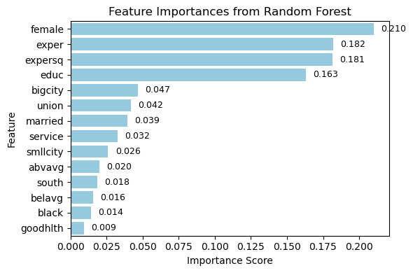

```python
# Analyze Feature Importance
best_rfr_model = best_rf_pipe.named_steps['rfr']
importances_rf = best_rfr_model.feature_importances_

# Create a DataFrame for visualization
feature_importance_rf_df = pd.DataFrame({'Feature': X_cols, 'Importance': importances_rf
                                        }).sort_values(by='Importance', ascending=False).reset_index(drop=True)

# Plot feature importances
plt.figure(figsize=(6, 4))
ax = sns.barplot(x='Importance', y='Feature', data=feature_importance_rf_df, color='skyblue')
for i, (importance, feature) in enumerate(zip(feature_importance_rf_df['Importance'], feature_importance_rf_df['Feature'])):
    ax.text(importance + 0.005, i, f"{importance:.3f}", va='center', fontsize=9)
plt.title('Feature Importances from Random Forest',size =12)
plt.xlabel('Importance Score', size=10)
plt.ylabel('Feature', size=10)
plt.tight_layout()
plt.show()
```

```python
# Predict and evaluate on lwage scale
y_test_pred = best_rf_pipe.predict(X_test_orig)
RMSE_lwage_rf = root_mean_squared_error(y_test_orig, y_test_pred)
r2_lwage_rf = best_rf_pipe.score(X_test_orig, y_test_orig) # R-squared on lwage

# Evaluate on the original wage scale
y_test_wage_pred = np.exp(y_test_pred) # Transform lwage to wage predictions
RMSE_wage_rf = root_mean_squared_error(y_test_wage, y_test_wage_pred)

print(f"\n--- Random Forests Results ---")
print(f"Random Forest RMSE (log wage scale): {RMSE_lwage_rf}")
print(f"Random Forest  R-squared (lwage scale): {r2_lwage_rf}")
print(f"Random Forest RMSE (wage scale): {RMSE_wage_rf}")
```

```
--- Random Forests Results ---
Random Forest RMSE (log wage scale): 0.4496394322341057
Random Forest  R-squared (lwage scale): 0.41117796879429824
Random Forest RMSE (wage scale): 3.592793131443144
```

**Random Forest Summary:** The model explains about 41% of the variance in log wages. *Female, exper, expersq, and educ* were identified as the most influential predictors, collectively accounting for ~74% of the total importance score in this model.

## 2.2. Neural Network (NN) Regression

The second additional model explored is Neural Network. A single validation set approach is used. The main training data is further split (75% NN-train / 25% NN-validation). Features are scaled using `StandardScaler` and fit only on the NN-training data.

```python
import tensorflow as tf
from tensorflow import keras

# Use the original train_set, test_set in part 1
# X_train_orig, y_train_orig
# X_test_orig, y_test_orig
# y_test_wage

# Using 25% of the X_train_orig for validation
X_train, X_valid, y_train, y_valid = train_test_split(X_train_orig, y_train_orig, test_size=0.25, random_state=42)

# Scale the features
scaler = StandardScaler()
X_train_scaled = scaler.fit_transform(X_train)
X_valid_scaled = scaler.transform(X_valid)
X_test_scaled = scaler.transform(X_test_orig)
```

### Build the Neural Network Model

After manually trying some combinations of hyperparameters, a sequential Keras model is defined with:

- An input layer (14 features).
- One hidden layer with 36 neurons using ReLU activation function.
- An output layer with a single neuron for regression.

```python
# Build the Neural Network Model
model_nn = keras.models.Sequential([
    keras.layers.InputLayer(shape=[X_train.shape[1]]),
    keras.layers.Dense(36, activation="relu"),   # first hidden layer
    keras.layers.Dense(1)                        # output layer
 ])
model_nn.summary() # Print model architecture
```

```
Model: "sequential_1"
```

```
┏━━━━━━━━━━━━━━━━━━━━━━━━━━━━━━━━━┳━━━━━━━━━━━━━━━━━━━━━━━━┳━━━━━━━━━━━━━━━┓
┃ Layer (type)                    ┃ Output Shape           ┃       Param # ┃
┡━━━━━━━━━━━━━━━━━━━━━━━━━━━━━━━━━╇━━━━━━━━━━━━━━━━━━━━━━━━╇━━━━━━━━━━━━━━━┩
│ dense_2 (Dense)                 │ (None, 36)             │           540 │
├─────────────────────────────────┼────────────────────────┼───────────────┤
│ dense_3 (Dense)                 │ (None, 1)              │            37 │
└─────────────────────────────────┴────────────────────────┴───────────────┘
```

```
 Total params: 577 (2.25 KB)
```

```
 Trainable params: 577 (2.25 KB)
```

```
 Non-trainable params: 0 (0.00 B)
```

### Compile and Train Model

The model is compiled using MSE loss and Adam optimizer (lr=0.001), and trained with early stopping

```python
# Compile the model
model_nn.compile(loss="mean_squared_error",
                 optimizer=keras.optimizers.Adam(learning_rate=0.001), # Adam optimizer
                 metrics=[tf.keras.metrics.RootMeanSquaredError()])

# Train the model with early stopping
early_stopping_cb = keras.callbacks.EarlyStopping(patience=15, restore_best_weights=True, monitor='val_loss', verbose=1)
history = model_nn.fit(X_train_scaled , y_train , epochs=100
                       , validation_data=(X_valid_scaled , y_valid)
                       , callbacks=[early_stopping_cb]
                      )
```

[output not shown]

[output cut: 30 more lines]

```
21/21 ━━━━━━━━━━━━━━━━━━━━ 0s 4ms/step - loss: 0.1324 - root_mean_squared_error: 0.3637 - val_loss: 0.3202 - val_root_mean_squared_error: 0.5659
21/21 ━━━━━━━━━━━━━━━━━━━━ 0s 5ms/step - loss: 0.1394 - root_mean_squared_error: 0.3731 - val_loss: 0.3218 - val_root_mean_squared_error: 0.5673
21/21 ━━━━━━━━━━━━━━━━━━━━ 0s 5ms/step - loss: 0.1347 - root_mean_squared_error: 0.3662 - val_loss: 0.3223 - val_root_mean_squared_error: 0.5677
21/21 ━━━━━━━━━━━━━━━━━━━━ 0s 5ms/step - loss: 0.1394 - root_mean_squared_error: 0.3732 - val_loss: 0.3212 - val_root_mean_squared_error: 0.5668
21/21 ━━━━━━━━━━━━━━━━━━━━ 0s 5ms/step - loss: 0.1316 - root_mean_squared_error: 0.3625 - val_loss: 0.3213 - val_root_mean_squared_error: 0.5669
21/21 ━━━━━━━━━━━━━━━━━━━━ 0s 5ms/step - loss: 0.1505 - root_mean_squared_error: 0.3877 - val_loss: 0.3219 - val_root_mean_squared_error: 0.5674
21/21 ━━━━━━━━━━━━━━━━━━━━ 0s 5ms/step - loss: 0.1455 - root_mean_squared_error: 0.3813 - val_loss: 0.3221 - val_root_mean_squared_error: 0.5675
21/21 ━━━━━━━━━━━━━━━━━━━━ 0s 5ms/step - loss: 0.1421 - root_mean_squared_error: 0.3766 - val_loss: 0.3223 - val_root_mean_squared_error: 0.5677
21/21 ━━━━━━━━━━━━━━━━━━━━ 0s 5ms/step - loss: 0.1217 - root_mean_squared_error: 0.3485 - val_loss: 0.3223 - val_root_mean_squared_error: 0.5677
21/21 ━━━━━━━━━━━━━━━━━━━━ 0s 5ms/step - loss: 0.1237 - root_mean_squared_error: 0.3512 - val_loss: 0.3237 - val_root_mean_squared_error: 0.5689
21/21 ━━━━━━━━━━━━━━━━━━━━ 0s 5ms/step - loss: 0.1305 - root_mean_squared_error: 0.3609 - val_loss: 0.3207 - val_root_mean_squared_error: 0.5663
21/21 ━━━━━━━━━━━━━━━━━━━━ 0s 5ms/step - loss: 0.1251 - root_mean_squared_error: 0.3533 - val_loss: 0.3220 - val_root_mean_squared_error: 0.5674
21/21 ━━━━━━━━━━━━━━━━━━━━ 0s 5ms/step - loss: 0.1416 - root_mean_squared_error: 0.3762 - val_loss: 0.3213 - val_root_mean_squared_error: 0.5669
Epoch 83: early stopping
Restoring model weights from the end of the best epoch: 68.
```

### Monitor Training Process

Neural networks have many tunable hyperparameters. While an exhaustive search is beyond the scope here, monitoring the training process helps assess the suitability of the chosen configuration.

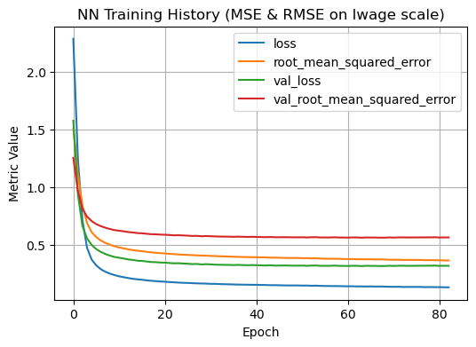

```python
import pandas as pd
import matplotlib.pyplot as plt

pd.DataFrame(history.history).plot(figsize=(6,4))
plt.grid(True)
plt.title("NN Training History (MSE & RMSE on lwage scale)")
plt.xlabel("Epoch")
plt.ylabel("Metric Value")
plt.show()
```

### Evaluate Neural Network

```python
# Evaluate on lwage scale
results_nn = model_nn.evaluate(X_test_scaled, y_test_orig)
y_test_pred = model_nn.predict(X_test_scaled).flatten() # Flatten output
RMSE_lwage_nn = results_nn[1]
r2_lwage_nn = r2_score(y_test_orig, y_test_pred)

# Make predictions and Evaluate on the wage scale
y_test_wage_pred = np.exp(y_test_pred)
RMSE_wage_nn = root_mean_squared_error(y_test_wage, y_test_wage_pred)

print(f"\n--- Neural Networks Results ---")
print(f"Neural Networks RMSE (log wage scale): {results_nn[1]}") # Index 1 corresponds to RootMeanSquaredError metric
print(f"Neural Networks  R-squared (lwage scale): {r2_lwage_nn}")
print(f"Neural Networks RMSE (wage scale): {RMSE_wage_nn}")
```

```
12/12 ━━━━━━━━━━━━━━━━━━━━ 0s 3ms/step - loss: 0.2210 - root_mean_squared_error: 0.4696
12/12 ━━━━━━━━━━━━━━━━━━━━ 0s 4ms/step

--- Neural Networks Results ---
Neural Networks RMSE (log wage scale): 0.4596092700958252
Neural Networks  R-squared (lwage scale): 0.3847765523523943
Neural Networks RMSE (wage scale): 3.6098844297052466
```

**Neural Network Summary:** The model explains about 38% of the variance in log wages. The above training history plot shows that training and validation losses decreased steadily, with early stopping at epoch 83 to prevent overfitting. The model showed effective learning behavior and appropriate hyperparameter tuning. While this architecture performs reasonably, further hyperparameter tuning could potentially improve results.

## 2.3. Model Comparison and Final Selection

We compare all four models based on RMSE (log wage and wage scale).

```python
# Consolidate results into a dictionary
results_data = {
    'RMSE (lwage scale)': [RMSE_lwage_ridge, RMSE_lwage_lasso, RMSE_lwage_rf, RMSE_lwage_nn],
    'RMSE (wage scale)': [RMSE_wage_ridge, RMSE_wage_lasso, RMSE_wage_rf, RMSE_wage_nn],
    'R-squared (lwage scale)': [r2_lwage_ridge, r2_lwage_lasso,r2_lwage_rf, r2_lwage_nn],
}

# Create DataFrame
results_df = pd.DataFrame(results_data, index=['Ridge', 'Lasso', 'Random Forests', 'Neural Networks'])
print ("The performance of four models is summarized below:\n")
display(results_df.style.format())
```

```
The performance of four models is summarized below:
```

|  | RMSE (lwage scale) | RMSE (wage scale) | R-squared (lwage scale) |
| --- | --- | --- | --- |
| Ridge | 0.440964 | 3.574057 | 0.433679 |
| Lasso | 0.441015 | 3.574414 | 0.433550 |
| Random Forests | 0.449639 | 3.592793 | 0.411178 |
| Neural Networks | 0.459609 | 3.609884 | 0.384777 |

**Discussion:**

- Comparing the RMSE, regularized linear models, **Ridge and Lasso, exhibit the best predictive performance**. They slightly outperform Random Forest and Neural Network.
- This outcome suggests that the underlying relationship between the predictors and log-wage is reasonably well-approximated by a linear specification, consistent with Mincer earnings function theory in economics (Mincer, 1974). The inclusion of `expersq` likely captures the expected non-linearity. More complex non-linear models (Random Forest and Neural Network) did not yield a significant predictive advantage here.

**Overall Preferred Model:**

- Both Ridge and Lasso are strong candidates. The exclusion of `looks` variable might already address multicollinearity concern, so Lasso did not perform further feature exclusion. The potential advantage of Lasso's sparsity is not realized here. Therefore, for this dataset, **Ridge is marginally preferred**. It achieved the slightly lowest RMSE and the highest R-squared (though differences are negligible).

**Ridge Coefficients:** The coefficient plot below (left panel) illustrates the estimated impact of each standardized predictor on log-wage

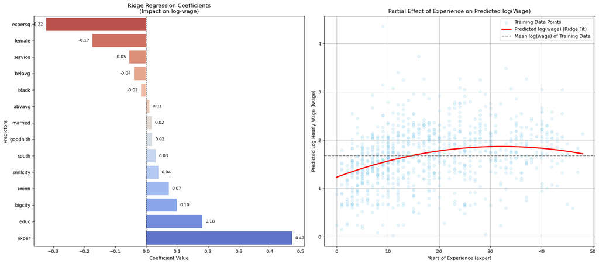

```python
fig, axes = plt.subplots(1, 2, figsize=(18, 8)) # 1 row, 2 columns

# --- Plot 1: Ridge Coefficients ---
ridge_coeffs_sorted = ridge_coeffs.sort_values()
sns.barplot(x=ridge_coeffs_sorted.values, y=ridge_coeffs_sorted.index,
            ax=axes[0], hue=ridge_coeffs_sorted.index, palette="coolwarm_r")
axes[0].axvline(0, color='black', linewidth=0.8, linestyle='--')
for i, value in enumerate(ridge_coeffs_sorted.values):
    axes[0].text(value + 0.01 * np.sign(value), i, f"{value:.2f}",
                 va='center', ha='left' if value > 0 else 'right', fontsize=9)
axes[0].set_title('Ridge Regression Coefficients\n(Impact on log-wage)')
axes[0].set_xlabel('Coefficient Value')
axes[0].set_ylabel('Predictors')

# --- Plot 2: Relationship between Experience and Hourly Wage ---
X_train_unscaled_df = pd.DataFrame(X_train_orig, columns=X_cols)
y_train_unscaled = y_train_orig
# 1. Create experience range
exper_min = X_train_unscaled_df['exper'].min()
exper_max = X_train_unscaled_df['exper'].max()
exper_range = np.linspace(exper_min, exper_max, 100)
expersq_range = exper_range**2

# 2. Create data for prediction, holding others constant at mean
means_other_vars = X_train_unscaled_df.drop(columns=['exper', 'expersq']).mean()
X_plot_unscaled = pd.DataFrame([means_other_vars.values] * len(exper_range), columns=means_other_vars.index)
# Add exper/expersq columns
X_plot_unscaled['exper'] = exper_range
X_plot_unscaled['expersq'] = expersq_range
X_plot_unscaled = X_plot_unscaled[X_cols] # Reorder to match original columns

# 3. Scale the plotting data
X_plot_scaled = scaler.transform(X_plot_unscaled)

# 4. Predict lwage using the scaled data
lwage_pred_curve = ridge_cv.predict(X_plot_scaled)

# 5. Create plot
axes[1].scatter(X_train_unscaled_df['exper'], y_train_unscaled, alpha=0.2, label='Training Data Points', color='skyblue')
axes[1].plot(exper_range, lwage_pred_curve, label='Predicted log(wage) (Ridge Fit)', color='red', linewidth=2.5)
axes[1].axhline(y=np.mean(y_train_unscaled), color='gray', linestyle='--', label='Mean log(wage) of Training Data')
axes[1].set_title('Partial Effect of Experience on Predicted log(Wage)')
axes[1].set_xlabel('Years of Experience (exper)')
axes[1].set_ylabel('Predicted Log Hourly Wage (lwage)')
axes[1].grid(True)
axes[1].legend()

# --- Final Figure Adjustments ---
plt.tight_layout()
plt.show()
```

## Reference

1. Mincer, J., 1974. Schooling, experience, and earnings. New York: Columbia University Press.